# High School Seniors t Test

```r
library(tidyverse)
library(DT)
library(pander)
library(readr)
library(car)
library(mosaic)

HSS <- read_csv("../../Data/HighSchoolSeniors.csv")
#If this code does not work:
#Use the top menu from RStudio's window to select "Session, Set Working Directory, To Source File Location", and then play this R-chunk into your console to read the HSS data into R.

## In your Console run View(HSS) to ensure the data has loaded correctly.
```

## Is there a difference between Male and Female Participants in Memory Scores and/or Reaction Times?

### Hypotheses

We understand men and women are different and can preform differently in various areas of achievement. Within our participants in the study is their a difference between how they preformed in memory scores or reaction times?

Null Hypothesis (H0): There is no significant relationship between gender and memory scores and/or reaction times.

Alternative Hypothesis (H1): That there is a difference between male and female participants with memory scores and/or reaction times.

We see from the two data tables we get from favstats that male and female participants scored close to each other. Now we can achieve a better understanding of the data by creating a box plot for each and running both through a t-test to confirm our hypothesis.

```r
# View(HSS)

sleep <- (HSS) %>%
  select(Gender, Ageyears, Score_in_memory_game, Reaction_time, Sleep_Hours_Schoolnight) %>%
  filter(!is.na(Sleep_Hours_Schoolnight),
         Sleep_Hours_Schoolnight < 20,
         !is.na(Score_in_memory_game),
         !is.na(Reaction_time),
         !is.na(Gender))

sleep_grouped <- sleep %>%
  mutate(Sleep_Hours_Categorical = case_when(
    Sleep_Hours_Schoolnight <=  6 ~ "Group 1 (≤ 6 hours)",
    Sleep_Hours_Schoolnight > 6 ~ "Group 2 (> 6 hours)"
  ))
# View(sleep)
```

### Gender and Memory Score Data

```r
favstats(sleep_grouped$Score_in_memory_game ~ sleep_grouped$Gender)
```

```
##   sleep_grouped$Gender    min Q1 median Q3 max     mean       sd   n missing
## 1               Female 28.000 39     45 49  79 45.66162  9.57798 198       0
## 2                 Male  0.353 38     46 53 137 46.51011 15.17898 218       0
```

### Gender and Reaction Time Data

```r
favstats(sleep_grouped$Reaction_time ~ sleep_grouped$Gender)
```

```
##   sleep_grouped$Gender   min      Q1 median      Q3   max      mean       sd
## 1               Female 0.168 0.36300 0.4270 0.51275 35.00 0.7452424 2.574422
## 2                 Male 0.010 0.31425 0.3625 0.44250 34.87 0.6057890 2.378789
##     n missing
## 1 198       0
## 2 218       0
```

## Gender and Memory Games

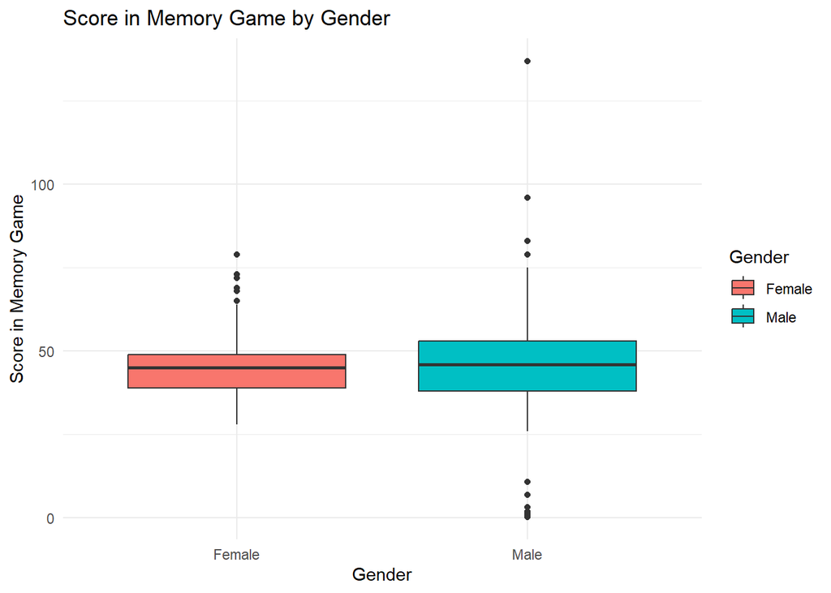

```r
ggplot(sleep_grouped, aes(x = Gender, y = Score_in_memory_game, fill = Gender)) +
  geom_boxplot() +
  labs(title = "Score in Memory Game by Gender",
       x = "Gender",
       y = "Score in Memory Game") +
  theme_minimal()
```

```r
t_test_memory <- t.test(Score_in_memory_game ~ Gender, data = sleep_grouped)
print(t_test_memory)
```

```
##
##  Welch Two Sample t-test
##
## data:  Score_in_memory_game by Gender
## t = -0.68817, df = 370.52, p-value = 0.4918
## alternative hypothesis: true difference in means between group Female and group Male is not equal to 0
## 95 percent confidence interval:
##  -3.272980  1.576002
## sample estimates:
## mean in group Female   mean in group Male
##             45.66162             46.51011
```

### Gender and Reaction Time

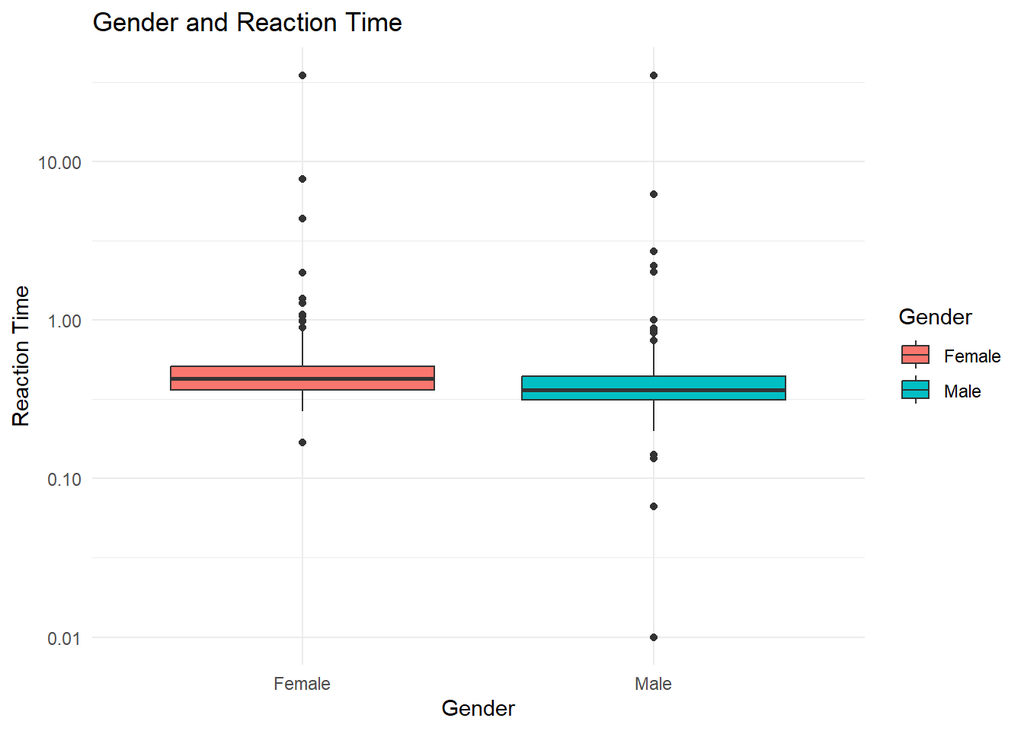

```r
ggplot(sleep_grouped, aes(x = Gender, y = Reaction_time, fill = Gender)) +
  geom_boxplot() +
  scale_y_log10() +
  labs(title = "Gender and Reaction Time",
       x = "Gender",
       y = "Reaction Time") +
  theme_minimal()
```

```r
t_test_reaction <- t.test(Reaction_time ~ Gender, data = sleep_grouped)
print(t_test_reaction)
```

```
##
##  Welch Two Sample t-test
##
## data:  Reaction_time by Gender
## t = 0.57204, df = 401.7, p-value = 0.5676
## alternative hypothesis: true difference in means between group Female and group Male is not equal to 0
## 95 percent confidence interval:
##  -0.3397958  0.6187027
## sample estimates:
## mean in group Female   mean in group Male
##            0.7452424            0.6057890
```

### Summary of Results

By looking at our chart we can see that the two genders are very similar when it comes to reaction time. And as we see in our p-value from the t-test we have a value 0.5676 causing us unable to reject the null hypothesis that there is no significant relationship between male and female and reaction time.

## Conclusion

We are unable to reject both null hypothesis leading to the conclusion that memory scores and reaction times are very similar between men and women in the study. Both p-values from our t-test were greater than 0.05, which means we do not have enough evidence to reject the null hypothesis for either memory scores or reaction times.